# Árboles de Clasificación y regresión

Introducción al Aprendizaje Estadístico

Kael Huerta, Enrique Bonilla

2016-07-06

### Nota: los paquetes que se utilizaran en estas notas son los siguientes:

```r
require(ggplot2)
require(ggdendro)
require(plyr)
require(dplyr)
require(tidyr)
require(kknn)
require(rpart)
require(tree)
require(mlbench)
require(randomForest)
require(gbm)
```

# Bagging, Bosques Aleatorios y Boosting

Recordemos: $E_{rr}(x_0) = \sigma_\epsilon^2 + sesgo_\gamma^2(x_0) + Var_\gamma(x_0)$

## Bagging

Intuitivamente, **bagging** es considerar la *sabiduría de las masas*. En lugar de estimar de un sólo árbol, ponderamos la opinión de muchos.

Consideremos $L^1, L^2, ..., L^B$ muestras **independientes** e idénticamente distribuidas del mismo fenómeno $F(x)$. Si con cada una obtenemos un árbol $T_{L^i}$, definimos
$$T'(x) = \frac{1}{B} \sum_{i=1}^B T_{L^i}(x)$$
como el *árbol bagging ideal* de manera que la predicción de $T'(x)$ es el promedio de los árboles $T_{L^i}(x)$. La pregunta es, ¿cómo se desempeña $T'$?

Por simplicidad, suponemos que el fenómeno tiene una respuesta cuantitativa.

Con respecto al sesgo podemos ver que
$$\begin{aligned}
E[T'(x)] &= \frac{1}{B} \sum_{i=1}^B T_{L^i}(x) \\
&= \frac{1}{B} \sum_{i=1}^B T_{L}(x) = E[T_L(x)]
\end{aligned}$$
Por lo que el sesgo de $T'$ es idéntico al de un único árbol.

Sin embargo, la varianza cambia de la siguiente manera
$$Var(T'(x)) = \frac{1}{B} Var(T_L(x))$$
a manera de que si $B$ es grande, el error cuadrático medio de $T'$ puede ser mucho menor que el de un árbol individual.

La parte relevante aquí es la palabra **independiente** de las muestras. Debido a que rara vez contamos con más de una muestra y difícilmente independientes entre sí, podemos utilizar muestras *bootstrap*.

Intuitivamente, si $F(x)$ es el mundo real y hacemos inferencia de él con una muestra $L$; *bootstrap* supone $L$ como el mundo real y hace inferencia de él con submuestras $L^{*i}$.

Sea $L = \{(x^i, y^i)_{i=1}^N\}$ una muestra de entrenamiento y sean $L^{*1}, L^{*2}, ..., L^{*B}$ muestras *bootstrap* de $L$. Es decir, cada $L^{*i}$ es una muestra con reemplazo de $(x^i, y^i) \in L$ con mismo tamaño de muestra $N$. Entonces el estimador *bagging por bootstrap* viene dado por:
$$\hat{T}^*(x) = \frac{1}{B} \sum_{i=1}^B T^{*i}(x)$$
para variable de respuesta cuantitativa. En el caso cualitativo:
$$\hat{T}^*(x) = argmax_g \{\sum_{i=1}^B I(T^{*i}(x) = g)\}$$

Por propiedades de *bootstrap* se puede ver que el sesgo de $T^*$ se mantiene. Para ver que pasa con el error cuadrático medio, se define $T^\dagger$ como el estimador *bootstrap* ideal que extrae muestras directamente de $F(x)$ tal que $T^\dagger(x) = E[T_L(x)]$. Entonces:
$$\begin{aligned}
E[F(x) - T_L(x)]^2 &= E[F(x) - T^\dagger(x) + T^\dagger(x) -
T_L(x)]^2 \\
&= E[F(x) - T^\dagger(x)]^2 + E[T_L(x) - T^\dagger(x)]^2 \\
&\geq E[F(x) - T^\dagger(x)]^2
\end{aligned}$$
Por lo tanto, vemos que al predecir con *bagging* tomando muestras de la población, el error cuadrático medio queda exactamente igual o mejora. En la práctica no se puede muestrear de la población original, por lo que esto sólo sugiere que *bootstrap* puede ayudar, pero no hay garantía.

Ojo: Esta afirmación no se mantiene para la pérdida 0-1. En este caso, *bagging* de malos estimadores puede empeorar la predicción.

Por esto, se busca la manera de *decorrelacionar* las muestras para mejorar el error cuadrático. Esto da pie a la técnica que veremos a continuación.

## Bosques Aleatorios

Como vimos, *bagging* puede mejorar la predicción. Sin embargo, no está garantizado pues las muestras *bootstrap* están correlacionadas entre sí.

En la práctica generalmente se tiene una mejora.

La pregunta es, ¿cómo afecta esta correlación?

Supongamos que tenemos $T^*(x)$ un árbol ajustado con *bagging* obtenido de muestras *bootstrap* de $F(x)$. Entonces, si condicionamos a la muestra de entrenamiento $L$, vemos que:
$$Var(T^*(x)) = E[Var(T^*(x)|L)] + Var(E[T^*(x)|L])$$
donde el primer término es la variación inducida por el remuestreo y el segundo es la varianza de cada submuestra.

Se puede ver que si
$$T(x) = \frac{1}{B} \sum_{i=1}^B T^{*i}(x)$$
es un modelo basado en árboles obtenidos de una muestra *bootstrap*, entonces
$$\begin{aligned}
Var(T(x)) &= \frac{1}{B} E[Var(T^*(x)|L)] + Var(E[T^*(x)|L]) \\
&= \frac{1}{B}E[Var(T^*(x)|L)] + Cov(T^{*i}(x), T^{*j}(x))
\end{aligned}$$

Esto porque $\begin{aligned} Var(E[T^*(x)|L]) &= E_L[(E[T^*(x)|L])^2] - (E[T^*(x)])^2 \\ &= E_L[E[T^{*i}(x)|L]E[T^{*j}(x)|L]] - (E[T^*(x)])^2 \\ &= E_L[E[T^{*i}(x)T^{*j}(x)|L]] - (E_L[E[T^*(x)|L]])^2 \\ &= Cov(T^{*i}(x), T^{*j}(x)) \end{aligned}$

Por lo que el error cuadrático medio decrece siempre que logremos *decorrelacionar* la manera como se construyen los árboles que conforman $T(x)$.

Esto lo logramos con **bosques aleatorios** de la siguiente forma:

1. Para $b = 1, 2, ..., B$ y $m \leq p$ fija

   $p$ es el número de variables en la muestra $L$
   - Seleccionar muestra *bootstrap* $L_b^*$ de $L$
   - Construir un árbol $T_b^*$ basado en $L_b^*$. Pero en cada nodo, consideramos al azar $m$ variables de las $p$ disponibles como candidatas para cortes.
2. El predictor está dado por
   $$T_{b.a.}(x) = \frac{i}{B} \sum_{b=1}^B T^{*b}(x)$$
   para regresión. Para clasificación por
   $$T_{b.a.}(x) = argmax_g \{ \sum_{b=1}^B I(T^{*b}(x) = g) \}$$

Por lo tanto, podemos pensar en **bosques aleatorios** como *bagging* con árboles *decorrelacionados*. Notemos que los parámetros para controlar la complejidad de los modelos vienen dados por $B$ el número de árboles y $m$ el número de variables candidatas a corte.

## Bosques Aleatorios en la práctica

A continuación algunas sugerencias de como buscar los valores de los parámetros de complejidad y algunas reglas de dedo.

Friedman, Hastie, and Tibshirani (2001)

Friedman, Jerome, Trevor Hastie, and Robert Tibshirani. 2001. *The Elements of Statistical Learning*. Vol. Second Edition. Springer series in statistics Springer, Berlin.

**$B$: Número de árboles**

Se elige minimizando una estimación honesta del error. Esto implica hacer $B$ muy grande hasta que dicha estimación se estabilice.

**$m$: Número de variables candidatas para corte**

La regla de dedo del autor (y del paquete de R) sugiere:

- $m = \lfloor p / 3 \rfloor$ para regresión
- $m = \lfloor \sqrt{p} \rfloor$ para clasificación

**Tamaño de árboles**

Dado que queremos incrementar la varianza de los árboles independientes, se recomienda considerar árboles sin podar. Este parámetro también se puede afinar.

## Estimación *Out-Of-Bag* (OOB) del error

El proceso de muestreo de los *bosques aleatorios* da una manera simple de construir una estimación honesta del error de predicción.

Sea $z_i = (x_i, y_i) \in L$. Definimos
$$T_{z_i} = \frac{1}{B_{z_i}} \sum_{z_i \notin L^{*j}} T^{*j}(x_i)$$
donde $B_{z_i} = \sum_j I(z_i \notin L^{*j})$. Es decir, construimos el predictor promediando sólo aquellos árboles que **no** usaron $z_i$ en su construcción.

Por lo tanto, la estimación *OOB* del error de prueba para el bosque es:
$$\hat{Err_{oob}} = \frac{1}{N} \sum_{i=1}^N(y_i - T_{z_i})^2$$

Es importante recalcar que si $B$ es grande, $\hat{Err_{oob}}$ es similar a la estimación por validación cruzada $N$. Sin necesidad de ajustar el modelo $N$ veces.

## Importancia de las variables

Otra bondad de los *bosques aleatorios* es que nos permiten calcular una medida de la importancia predictiva de las variables de entrada.

Para calcular dicha medida, consideremos un árbol $T^{*j}$. Usando la muestra *OOB* de $T^{*j}$, que es $L - L^{*j}$, estimamos su error *OOB*:
$$\hat{Err_{oob}} = \frac{1}{A_j} \sum_{z_i \in L - L^{*j}}
(y_i - T^{*j}(x_i)^2)$$
donde $z_i$ = (x_i, y_i)$ y $A_i = |L - L^{*j}|$ (el tamaño de muestra *OOB*).

Ahora, permutamos los valores de la variable $X_j$ en la muestra *OOB* para hacer algo similar a un análisis de sensibilidad y calculamos $\hat{Err_{oob}}(T^{*j})$ con la muestra *OOB* con la $k$-ésima variable permutada.

Finalmente, promediamos sobre el bosque
$$\hat{Imp}(k) = \frac{1}{B} \sum_{j=1}^B (\hat{Err_k(T^{*j}) -
\hat{Err_{oob}}(T^{*j}))$$
y denotamos esta medida como la *importancia relativa de la variable $x_j$*.

Podemos interpretar la importancia como el decremento en precisión que resulta de *quitar* la variable $x_j$.

```
## data.table + dplyr code now lives in dtplyr.
## Please library(dtplyr)!
```

Error Out-Of-Bag para selección de parámetros

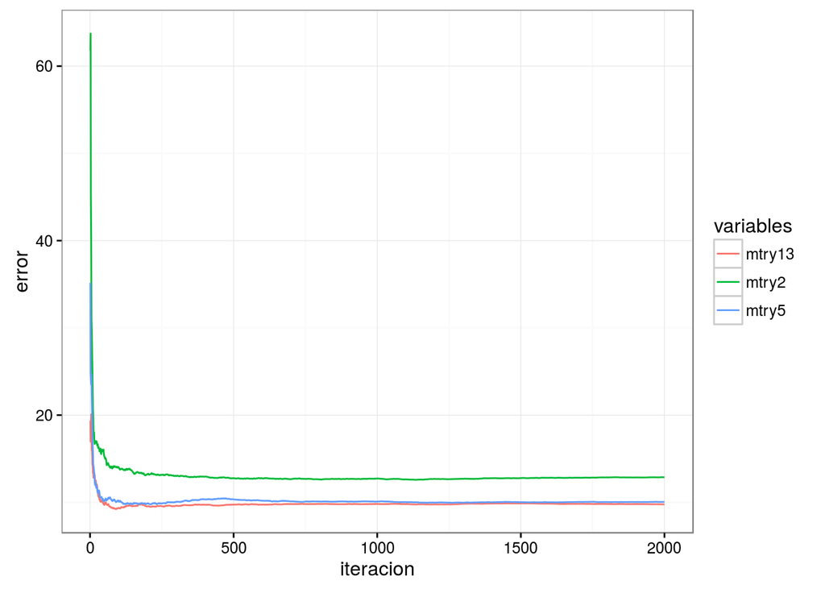

```r
## Método: RandomForest
## Datos: Boston Housing (librería mlbench)
## Librerías: randomForest

b <- 2000

## Probamos con distintos parámetros
bosque.2 <- entrena.arb %>%
  randomForest(medv ~ ., data = ., ntree = b, mtry = 2)
bosque.5 <- entrena.arb %>%
  randomForest(medv ~ ., data = ., ntree = b, mtry = 5)
bosque.13 <- entrena.arb %>%
  randomForest(medv ~ ., data = ., ntree = b, mtry = 13)

data.table(iteracion = 1:b,
    mtry2 = bosque.2$mse,
    mtry5 = bosque.5$mse,
    mtry13 = bosque.13$mse) %>%
  gather(variables, error, -iteracion) %>%
  ggplot(aes(x = iteracion, y = error, colour = variables, group = variables)) +
    geom_line()
```

```r
## Nos quedamos con los mejores parámetros
bosque <- entrena.arb %>%
  randomForest(medv ~ ., data = ., ntree = 1000, do.trace = 100, mtry = 13)
```

```
##      |      Out-of-bag   |
## Tree |      MSE  %Var(y) |
##  100 |    9.891    11.74 |
##  200 |    9.616    11.41 |
##  300 |     9.64    11.44 |
##  400 |    9.476    11.25 |
##  500 |    9.589    11.38 |
##  600 |    9.551    11.34 |
##  700 |    9.555    11.34 |
##  800 |     9.53    11.31 |
##  900 |    9.567    11.35 |
## 1000 |    9.648    11.45 |
```

Importancia de las Variables

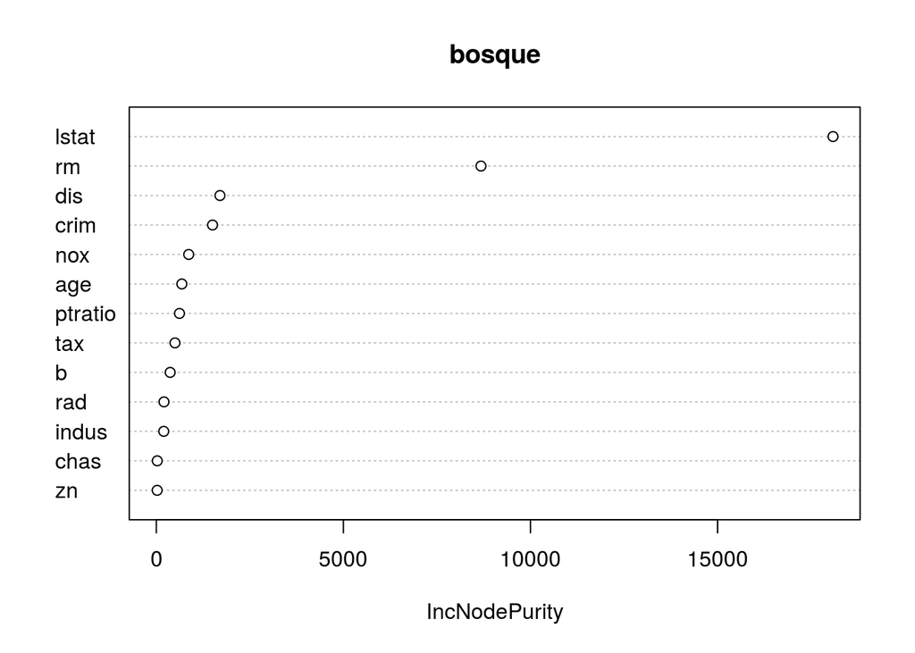

```r
varImpPlot(bosque)
```

```r
## Error cuadrático medio
## Recordemos que el de árboles de decisión era de ~ 17
mean((predict(bosque, prueba.arb) - prueba.arb$medv)^2)
```

```
## [1] 9.121404
```